# Predictive analysis of customer behaviour for retention

#### Logistic Regression

```python
# Grid searching key hyperparameters for logistic regression

from sklearn.datasets import make_blobs
from sklearn.model_selection import RepeatedStratifiedKFold
from sklearn.model_selection import GridSearchCV
from sklearn.linear_model import LogisticRegression

# Create object of the class

LRmodel_hpt = LogisticRegression()

# Parameters

solvers = ['newton-cg', 'lbfgs', 'liblinear']
penalty = ['l2']
c_values = [100, 10, 1.0, 0.1, 0.01]


# Define grid search

grid = dict(solver=solvers,penalty=penalty,C=c_values)
cv = RepeatedStratifiedKFold(n_splits=10, n_repeats=3, random_state=123)
grid_search = GridSearchCV(estimator=LRmodel_hpt, param_grid=grid, n_jobs=-1, cv=cv, scoring='accuracy',error_score=0)
grid_result = grid_search.fit(x_train, y_train)

# Results

print("Best: %f using %s" % (grid_result.best_score_, grid_result.best_params_))
means = grid_result.cv_results_['mean_test_score']
stds = grid_result.cv_results_['std_test_score']
params = grid_result.cv_results_['params']
for mean, stdev, param in zip(means, stds, params):
    print("%f (%f) with: %r" % (mean, stdev, param))
```

```
Best: 0.805998 using {'C': 1.0, 'penalty': 'l2', 'solver': 'newton-cg'}
0.805762 (0.018743) with: {'C': 100, 'penalty': 'l2', 'solver': 'newton-cg'}
0.805762 (0.018743) with: {'C': 100, 'penalty': 'l2', 'solver': 'lbfgs'}
0.805762 (0.018743) with: {'C': 100, 'penalty': 'l2', 'solver': 'liblinear'}
0.805407 (0.019048) with: {'C': 10, 'penalty': 'l2', 'solver': 'newton-cg'}
0.805347 (0.019008) with: {'C': 10, 'penalty': 'l2', 'solver': 'lbfgs'}
0.805347 (0.019008) with: {'C': 10, 'penalty': 'l2', 'solver': 'liblinear'}
0.805998 (0.018657) with: {'C': 1.0, 'penalty': 'l2', 'solver': 'newton-cg'}
0.805998 (0.018657) with: {'C': 1.0, 'penalty': 'l2', 'solver': 'lbfgs'}
0.805880 (0.018617) with: {'C': 1.0, 'penalty': 'l2', 'solver': 'liblinear'}
0.803454 (0.018911) with: {'C': 0.1, 'penalty': 'l2', 'solver': 'newton-cg'}
0.803454 (0.018911) with: {'C': 0.1, 'penalty': 'l2', 'solver': 'lbfgs'}
0.803513 (0.019109) with: {'C': 0.1, 'penalty': 'l2', 'solver': 'liblinear'}
0.804221 (0.018351) with: {'C': 0.01, 'penalty': 'l2', 'solver': 'newton-cg'}
0.804221 (0.018351) with: {'C': 0.01, 'penalty': 'l2', 'solver': 'lbfgs'}
0.800792 (0.020254) with: {'C': 0.01, 'penalty': 'l2', 'solver': 'liblinear'}
```

**Observations:**

**Testing model with best parameters**

```python
from sklearn.linear_model import LogisticRegression

#Create an object of the class

# Using the best parameters from the gridsearch. C and penalty default values are same.
LogisticRegression_tuned = LogisticRegression(solver='newton-cg')

#Train the model

LRmodel_tuned = LogisticRegression_tuned.fit(x_train,y_train)

#Prediction

#Train set
LR_y_pred_train_tuned = LRmodel_tuned.predict(x_train)

#Test set
LR_y_pred_test_tuned = LRmodel_tuned.predict(x_test)

# generate evaluation metrics

#Accuracy
print ("\nTrain Accuracy after Hyperparameter tuning :", metrics.accuracy_score(y_train, LR_y_pred_train_tuned))
print ("\nTest Accuracy after Hyperparameter tuning:", metrics.accuracy_score(y_test, LR_y_pred_test_tuned))

#Area under curve
print ("\nTrain AUC after Hyperparameter tuning:", metrics.roc_auc_score(y_train, LR_y_pred_train_tuned))
print ("\nTest AUC after Hyperparameter tuning:", metrics.roc_auc_score(y_test, LR_y_pred_test_tuned))

#Confusion matrix of test
print ("\nConfusion matrix after Hyperparameter tuning:\n\n",metrics.confusion_matrix(y_test,LR_y_pred_test_tuned))

#Classification report of test
print ("\nclassification report Hyperparameter tuning:\n\n\n", metrics.classification_report(y_test,LR_y_pred_test_tuned))
```

```
Train Accuracy after Hyperparameter tuning : 0.807596734114306

Test Accuracy after Hyperparameter tuning: 0.7970191625266146

Train AUC after Hyperparameter tuning: 0.7282577586074546

Test AUC after Hyperparameter tuning: 0.7098581725180191

Confusion matrix after Hyperparameter tuning:

 [[927 108]
 [178 196]]

classification report Hyperparameter tuning:


               precision    recall  f1-score   support

           0       0.84      0.90      0.87      1035
           1       0.64      0.52      0.58       374

    accuracy                           0.80      1409
   macro avg       0.74      0.71      0.72      1409
weighted avg       0.79      0.80      0.79      1409
```

**Observations:**

- The **train accuracy** after hyperparameter tuning is 0.807596734114306, indicating that the model correctly predicted the class labels for the training data with an accuracy of approximately **81%.**
- The **test accuracy** after hyperparameter tuning is 0.7970191625266146, indicating that the model correctly predicted the class labels for the testing data with an accuracy of approximately **80%.**
- The **train AUC** after hyperparameter tuning is 0.7282577586074546, indicating that the model has some ability to distinguish between positive and negative class examples in the training data.
- The **test AUC** after hyperparameter tuning is 0.7098581725180191, indicating that the model has some ability to distinguish between positive and negative class examples in the testing data.
- The **confusion matrix** after hyperparameter tuning shows that the model predicted 927 true negatives, 108 false positives, 178 false negatives, and 196 true positives.  
  Overall, it appears that the hyperparameter tuning process resulted in a model that is able to accurately predict class labels with reasonable accuracy and has some ability to distinguish between positive and negative class examples, although there is some room for improvement.

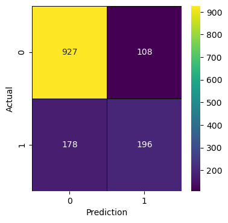

```python
# Confusion Matrix visualization

LR_confusion_matrix_tuned = metrics.confusion_matrix(y_test,LR_y_pred_test_tuned)


f, ax = plt.subplots(figsize=(4,4))
sns.heatmap(LR_confusion_matrix_tuned,annot = True, linewidths=0.5,linecolor="black",fmt=".0f",ax=ax,cmap='viridis')
plt.xlabel("Prediction")
plt.ylabel("Actual")
plt.show()
```

**Observations:**  
The **confusion matrix** after hyperparameter tuning shows that the model predicted 927 true negatives, 108 false positives, 178 false negatives, and 196 true positives.

**Using SMOTE train-test-split**

```python
# Grid searching key hyperparameters for logistic regression

from sklearn.datasets import make_blobs
from sklearn.model_selection import RepeatedStratifiedKFold
from sklearn.model_selection import GridSearchCV
from sklearn.linear_model import LogisticRegression

# Create object of the class

LRmodel_hpt = LogisticRegression()

# Parameters

solvers = ['newton-cg', 'lbfgs', 'liblinear']
penalty = ['l2']
c_values = [100, 10, 1.0, 0.1, 0.01]


# Define grid search

grid = dict(solver=solvers,penalty=penalty,C=c_values)
cv = RepeatedStratifiedKFold(n_splits=10, n_repeats=3, random_state=123)
grid_search = GridSearchCV(estimator=LRmodel_hpt, param_grid=grid, n_jobs=-1, cv=cv, scoring='accuracy',error_score=0)
grid_result = grid_search.fit(x_train_sm, y_train_sm)

# Results

print("Best: %f using %s" % (grid_result.best_score_, grid_result.best_params_))
means = grid_result.cv_results_['mean_test_score']
stds = grid_result.cv_results_['std_test_score']
params = grid_result.cv_results_['params']
for mean, stdev, param in zip(means, stds, params):
    print("%f (%f) with: %r" % (mean, stdev, param))
```

```
Best: 0.778127 using {'C': 100, 'penalty': 'l2', 'solver': 'lbfgs'}
0.778086 (0.014361) with: {'C': 100, 'penalty': 'l2', 'solver': 'newton-cg'}
0.778127 (0.014311) with: {'C': 100, 'penalty': 'l2', 'solver': 'lbfgs'}
0.778086 (0.014372) with: {'C': 100, 'penalty': 'l2', 'solver': 'liblinear'}
0.777885 (0.014491) with: {'C': 10, 'penalty': 'l2', 'solver': 'newton-cg'}
0.777885 (0.014491) with: {'C': 10, 'penalty': 'l2', 'solver': 'lbfgs'}
0.777845 (0.014493) with: {'C': 10, 'penalty': 'l2', 'solver': 'liblinear'}
0.777160 (0.014885) with: {'C': 1.0, 'penalty': 'l2', 'solver': 'newton-cg'}
0.777160 (0.014885) with: {'C': 1.0, 'penalty': 'l2', 'solver': 'lbfgs'}
0.777120 (0.015034) with: {'C': 1.0, 'penalty': 'l2', 'solver': 'liblinear'}
0.776032 (0.014511) with: {'C': 0.1, 'penalty': 'l2', 'solver': 'newton-cg'}
0.776032 (0.014511) with: {'C': 0.1, 'penalty': 'l2', 'solver': 'lbfgs'}
0.776113 (0.014844) with: {'C': 0.1, 'penalty': 'l2', 'solver': 'liblinear'}
0.770878 (0.014686) with: {'C': 0.01, 'penalty': 'l2', 'solver': 'newton-cg'}
0.770878 (0.014686) with: {'C': 0.01, 'penalty': 'l2', 'solver': 'lbfgs'}
0.771804 (0.014690) with: {'C': 0.01, 'penalty': 'l2', 'solver': 'liblinear'}
```

**Obeservation:**

```python
from sklearn.linear_model import LogisticRegression

#Create an object of the class

# Using the best parameters from the gridsearch. penalty default values are same.
LogisticRegression_tuned_sm = LogisticRegression(solver='lbfgs')

#Train the model

LRmodel_tuned_sm= LogisticRegression_tuned.fit(x_train_sm,y_train_sm)

#Prediction

#Train set
LR_y_pred_train_tuned_sm = LRmodel_tuned_sm.predict(x_train_sm)

#Test set
LR_y_pred_test_tuned_sm = LRmodel_tuned_sm.predict(x_test_sm)

# generate evaluation metrics

#Accuracy
print ("\nTrain Accuracy after Hyperparameter tuning :", metrics.accuracy_score(y_train_sm, LR_y_pred_train_tuned_sm))
print ("\nTest Accuracy after Hyperparameter tuning:", metrics.accuracy_score(y_test_sm, LR_y_pred_test_tuned_sm))

#Area under curve
print ("\nTrain AUC after Hyperparameter tuning:", metrics.roc_auc_score(y_train_sm, LR_y_pred_train_tuned_sm))
print ("\nTest AUC after Hyperparameter tuning:", metrics.roc_auc_score(y_test_sm, LR_y_pred_test_tuned_sm))

#Confusion matrix of test
print ("\nConfusion matrix after Hyperparameter tuning:\n\n",metrics.confusion_matrix(y_test_sm,LR_y_pred_test_tuned_sm))

#Classification report of test
print ("\nclassification report Hyperparameter tuning:\n\n\n", metrics.classification_report(y_test_sm,LR_y_pred_test_tuned_sm))
```

```
Train Accuracy after Hyperparameter tuning : 0.7800193283401788

Test Accuracy after Hyperparameter tuning: 0.7840579710144927

Train AUC after Hyperparameter tuning: 0.7800193283401787

Test AUC after Hyperparameter tuning: 0.7840579710144926

Confusion matrix after Hyperparameter tuning:

 [[772 263]
 [184 851]]

classification report Hyperparameter tuning:


               precision    recall  f1-score   support

           0       0.81      0.75      0.78      1035
           1       0.76      0.82      0.79      1035

    accuracy                           0.78      2070
   macro avg       0.79      0.78      0.78      2070
weighted avg       0.79      0.78      0.78      2070
```

**Observations:**

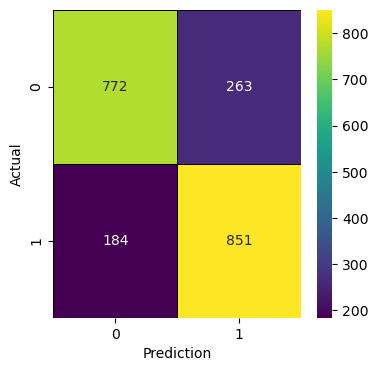

```python
# Confusion Matrix visualization

LR_confusion_matrix_tuned_sm = metrics.confusion_matrix(y_test_sm,LR_y_pred_test_tuned_sm)


f, ax = plt.subplots(figsize=(4,4))
sns.heatmap(LR_confusion_matrix_tuned_sm,annot = True, linewidths=0.5,linecolor="black",fmt=".0f",ax=ax,cmap='viridis')
plt.xlabel("Prediction")
plt.ylabel("Actual")
plt.show()
```

**Observations:**

##### Decision Tree Classification

```python
# Grid searching key hyperparameters for Decision Tree Classification

from sklearn.tree import DecisionTreeClassifier

# Create object of the class

DTmodel_hpt = DecisionTreeClassifier()

# Parameters

params = {
    'max_depth': [2, 3, 5, 10, 20],
    'min_samples_leaf': [5, 10, 20, 50, 100],
    'criterion': ["gini", "entropy"],
    'max_features': [10,15,20,25,30]
}



# Define grid search

cv = RepeatedStratifiedKFold(n_splits=10, n_repeats=3, random_state=123)
grid_search = GridSearchCV(estimator=DTmodel_hpt, param_grid=params, n_jobs=-1, cv=cv, scoring='accuracy',error_score=0)
grid_result = grid_search.fit(x_train, y_train)

# Results

print("Best: %f using %s" % (grid_result.best_score_, grid_result.best_params_))
means = grid_result.cv_results_['mean_test_score']
stds = grid_result.cv_results_['std_test_score']
params = grid_result.cv_results_['params']
for mean, stdev, param in zip(means, stds, params):
    print("%f (%f) with: %r" % (mean, stdev, param))
```

```
Best: 0.792512 using {'criterion': 'entropy', 'max_depth': 10, 'max_features': 30, 'min_samples_leaf': 100}
0.756240 (0.023660) with: {'criterion': 'gini', 'max_depth': 2, 'max_features': 10, 'min_samples_leaf': 5}
0.752631 (0.021357) with: {'criterion': 'gini', 'max_depth': 2, 'max_features': 10, 'min_samples_leaf': 10}
0.755646 (0.025817) with: {'criterion': 'gini', 'max_depth': 2, 'max_features': 10, 'min_samples_leaf': 20}
0.756830 (0.023249) with: {'criterion': 'gini', 'max_depth': 2, 'max_features': 10, 'min_samples_leaf': 50}
0.754760 (0.023709) with: {'criterion': 'gini', 'max_depth': 2, 'max_features': 10, 'min_samples_leaf': 100}
0.771793 (0.024404) with: {'criterion': 'gini', 'max_depth': 2, 'max_features': 15, 'min_samples_leaf': 5}
0.764638 (0.025662) with: {'criterion': 'gini', 'max_depth': 2, 'max_features': 15, 'min_samples_leaf': 10}
0.769850 (0.023017) with: {'criterion': 'gini', 'max_depth': 2, 'max_features': 15, 'min_samples_leaf': 20}
0.773927 (0.022442) with: {'criterion': 'gini', 'max_depth': 2, 'max_features': 15, 'min_samples_leaf': 50}
0.770734 (0.024986) with: {'criterion': 'gini', 'max_depth': 2, 'max_features': 15, 'min_samples_leaf': 100}
0.773335 (0.025630) with: {'criterion': 'gini', 'max_depth': 2, 'max_features': 20, 'min_samples_leaf': 5}
0.778417 (0.022401) with: {'criterion': 'gini', 'max_depth': 2, 'max_features': 20, 'min_samples_leaf': 10}
0.773510 (0.020064) with: {'criterion': 'gini', 'max_depth': 2, 'max_features': 20, 'min_samples_leaf': 20}
0.777537 (0.024035) with: {'criterion': 'gini', 'max_depth': 2, 'max_features': 20, 'min_samples_leaf': 50}
0.783924 (0.022607) with: {'criterion': 'gini', 'max_depth': 2, 'max_features': 20, 'min_samples_leaf': 100}
0.783454 (0.019038) with: {'criterion': 'gini', 'max_depth': 2, 'max_features': 25, 'min_samples_leaf': 5}
0.781500 (0.018767) with: {'criterion': 'gini', 'max_depth': 2, 'max_features': 25, 'min_samples_leaf': 10}
0.783865 (0.017922) with: {'criterion': 'gini', 'max_depth': 2, 'max_features': 25, 'min_samples_leaf': 20}
0.782148 (0.019794) with: {'criterion': 'gini', 'max_depth': 2, 'max_features': 25, 'min_samples_leaf': 50}
0.780551 (0.025589) with: {'criterion': 'gini', 'max_depth': 2, 'max_features': 25, 'min_samples_leaf': 100}
0.786351 (0.017582) with: {'criterion': 'gini', 'max_depth': 2, 'max_features': 30, 'min_samples_leaf': 5}
0.786351 (0.017582) with: {'criterion': 'gini', 'max_depth': 2, 'max_features': 30, 'min_samples_leaf': 10}
0.786351 (0.017582) with: {'criterion': 'gini', 'max_depth': 2, 'max_features': 30, 'min_samples_leaf': 20}
0.786351 (0.017582) with: {'criterion': 'gini', 'max_depth': 2, 'max_features': 30, 'min_samples_leaf': 50}
0.786351 (0.017582) with: {'criterion': 'gini', 'max_depth': 2, 'max_features': 30, 'min_samples_leaf': 100}
0.775055 (0.020198) with: {'criterion': 'gini', 'max_depth': 3, 'max_features': 10, 'min_samples_leaf': 5}
0.775167 (0.022102) with: {'criterion': 'gini', 'max_depth': 3, 'max_features': 10, 'min_samples_leaf': 10}
0.769081 (0.019826) with: {'criterion': 'gini', 'max_depth': 3, 'max_features': 10, 'min_samples_leaf': 20}
0.771628 (0.018319) with: {'criterion': 'gini', 'max_depth': 3, 'max_features': 10, 'min_samples_leaf': 50}
0.775408 (0.019979) with: {'criterion': 'gini', 'max_depth': 3, 'max_features': 10, 'min_samples_leaf': 100}
0.782568 (0.019281) with: {'criterion': 'gini', 'max_depth': 3, 'max_features': 15, 'min_samples_leaf': 5}
0.779014 (0.025005) with: {'criterion': 'gini', 'max_depth': 3, 'max_features': 15, 'min_samples_leaf': 10}
0.782332 (0.018351) with: {'criterion': 'gini', 'max_depth': 3, 'max_features': 15, 'min_samples_leaf': 20}
0.781502 (0.017140) with: {'criterion': 'gini', 'max_depth': 3, 'max_features': 15, 'min_samples_leaf': 50}
0.782097 (0.017030) with: {'criterion': 'gini', 'max_depth': 3, 'max_features': 15, 'min_samples_leaf': 100}
0.782093 (0.014302) with: {'criterion': 'gini', 'max_depth': 3, 'max_features': 20, 'min_samples_leaf': 5}
0.785167 (0.016474) with: {'criterion': 'gini', 'max_depth': 3, 'max_features': 20, 'min_samples_leaf': 10}
0.785524 (0.018620) with: {'criterion': 'gini', 'max_depth': 3, 'max_features': 20, 'min_samples_leaf': 20}
0.786706 (0.016821) with: {'criterion': 'gini', 'max_depth': 3, 'max_features': 20, 'min_samples_leaf': 50}
```

[output cut: 196 more lines]

```
0.754765 (0.014900) with: {'criterion': 'entropy', 'max_depth': 20, 'max_features': 20, 'min_samples_leaf': 5}
0.772216 (0.015893) with: {'criterion': 'entropy', 'max_depth': 20, 'max_features': 20, 'min_samples_leaf': 10}
0.780443 (0.015679) with: {'criterion': 'entropy', 'max_depth': 20, 'max_features': 20, 'min_samples_leaf': 20}
0.786893 (0.014772) with: {'criterion': 'entropy', 'max_depth': 20, 'max_features': 20, 'min_samples_leaf': 50}
0.791741 (0.016197) with: {'criterion': 'entropy', 'max_depth': 20, 'max_features': 20, 'min_samples_leaf': 100}
0.753699 (0.018461) with: {'criterion': 'entropy', 'max_depth': 20, 'max_features': 25, 'min_samples_leaf': 5}
0.776658 (0.015721) with: {'criterion': 'entropy', 'max_depth': 20, 'max_features': 25, 'min_samples_leaf': 10}
0.780739 (0.015692) with: {'criterion': 'entropy', 'max_depth': 20, 'max_features': 25, 'min_samples_leaf': 20}
0.788489 (0.015548) with: {'criterion': 'entropy', 'max_depth': 20, 'max_features': 25, 'min_samples_leaf': 50}
0.790322 (0.018301) with: {'criterion': 'entropy', 'max_depth': 20, 'max_features': 25, 'min_samples_leaf': 100}
0.751629 (0.015262) with: {'criterion': 'entropy', 'max_depth': 20, 'max_features': 30, 'min_samples_leaf': 5}
0.775177 (0.013480) with: {'criterion': 'entropy', 'max_depth': 20, 'max_features': 30, 'min_samples_leaf': 10}
0.782337 (0.015902) with: {'criterion': 'entropy', 'max_depth': 20, 'max_features': 30, 'min_samples_leaf': 20}
0.787424 (0.016517) with: {'criterion': 'entropy', 'max_depth': 20, 'max_features': 30, 'min_samples_leaf': 50}
0.792512 (0.014812) with: {'criterion': 'entropy', 'max_depth': 20, 'max_features': 30, 'min_samples_leaf': 100}
```

**Testing model with best parameters**

```python
from sklearn.tree import DecisionTreeClassifier
# Create an object of the class

# Using the best parameters from gridsearch

DecisionTreeClassifier_tuned = DecisionTreeClassifier(max_depth=10, max_features=30,criterion='entropy',min_samples_leaf=100)

# Train your model

DTmodel_tuned = DecisionTreeClassifier_tuned.fit(x_train,y_train)

#Prediction

#Train set
DT_y_pred_train_tuned = DTmodel_tuned.predict(x_train)

#Test set
DT_y_pred_test_tuned = DTmodel_tuned.predict(x_test)

# generate evaluation metrics

#Accuracy
print ("\nTrain Accuracy after Hyperparameter tuning:", metrics.accuracy_score(y_train, DT_y_pred_train_tuned))
print ("\nTest Accuracy after Hyperparameter tuning:", metrics.accuracy_score(y_test, DT_y_pred_test_tuned))

#Area under curve
print ("\nTrain AUC after Hyperparameter tuning:", metrics.roc_auc_score(y_train, DT_y_pred_train_tuned))
print ("\nTest AUC after Hyperparameter tuning:", metrics.roc_auc_score(y_test, DT_y_pred_test_tuned))

#Confusion matrix of test
print ("\nConfusion matrix after Hyperparameter tuning:\n\n",metrics.confusion_matrix(y_test,DT_y_pred_test_tuned))

#Classification report of test
print ("\nclassification report after Hyperparameter tuning:\n\n\n", metrics.classification_report(y_test,DT_y_pred_test_tuned))
```

```
Train Accuracy after Hyperparameter tuning: 0.8058217962371317

Test Accuracy after Hyperparameter tuning: 0.7970191625266146

Train AUC after Hyperparameter tuning: 0.6932936639082841

Test AUC after Hyperparameter tuning: 0.673998294970162

Confusion matrix after Hyperparameter tuning:

 [[969  66]
 [220 154]]

classification report after Hyperparameter tuning:


               precision    recall  f1-score   support

           0       0.81      0.94      0.87      1035
           1       0.70      0.41      0.52       374

    accuracy                           0.80      1409
   macro avg       0.76      0.67      0.69      1409
weighted avg       0.78      0.80      0.78      1409
```

**Observation:**

- The results show that the model achieved a train accuracy of 0.8058 and a test accuracy of 0.7970.
- The train and test AUC scores after hyperparameter tuning are 0.6932 and 0.6740, respectively, indicating that the model's ability to distinguish between positive and negative classes is not very high.
- The confusion matrix shows that the model correctly classified 969 instances of the negative class and 154 instances of the positive class, while incorrectly classifying 220 instances of the positive class and 66 instances of the negative class.
- The classification report shows that the precision of the model is 0.81 for the negative class and 0.70 for the positive class, while the recall is 0.94 for the negative class and 0.41 for the positive class. The F1-score is 0.87 for the negative class and 0.52 for the positive class.  
  Overall, the model seems to perform reasonably well on the negative class, but not as well on the positive class. It may be worth exploring other classification models.

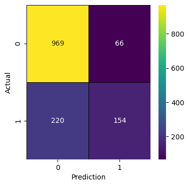

```python
# Confusion Matrix visualization

DT_confusion_matrix_tuned = metrics.confusion_matrix(y_test,DT_y_pred_test_tuned)


f, ax = plt.subplots(figsize=(4,4))
sns.heatmap(DT_confusion_matrix_tuned,annot = True, linewidths=0.5,linecolor="black",fmt=".0f",ax=ax,cmap='viridis')
plt.xlabel("Prediction")
plt.ylabel("Actual")
plt.show()
```

**Observations:**  
The confusion matrix shows that the model correctly classified 969 instances of the negative class and 154 instances of the positive class, while incorrectly classifying 220 instances of the positive class and 66 instances of the negative class.

**Using SMOTE train-test-split**

```python
# Grid searching key hyperparameters for Decision Tree Classification

from sklearn.tree import DecisionTreeClassifier

# Create object of the class

DTmodel_hpt = DecisionTreeClassifier()

# Parameters

params = {
    'max_depth': [2, 3, 5, 10, 20],
    'min_samples_leaf': [5, 10, 20, 50, 100],
    'criterion': ["gini", "entropy"],
    'max_features': [10,15,20,25,30]
}



# Define grid search

cv = RepeatedStratifiedKFold(n_splits=10, n_repeats=3, random_state=123)
grid_search = GridSearchCV(estimator=DTmodel_hpt, param_grid=params, n_jobs=-1, cv=cv, scoring='accuracy',error_score=0)
grid_result = grid_search.fit(x_train_sm, y_train_sm)

# Results

print("Best: %f using %s" % (grid_result.best_score_, grid_result.best_params_))
means = grid_result.cv_results_['mean_test_score']
stds = grid_result.cv_results_['std_test_score']
params = grid_result.cv_results_['params']
for mean, stdev, param in zip(means, stds, params):
    print("%f (%f) with: %r" % (mean, stdev, param))
```

```
Best: 0.798905 using {'criterion': 'entropy', 'max_depth': 10, 'max_features': 30, 'min_samples_leaf': 10}
0.711481 (0.023070) with: {'criterion': 'gini', 'max_depth': 2, 'max_features': 10, 'min_samples_leaf': 5}
0.706251 (0.026900) with: {'criterion': 'gini', 'max_depth': 2, 'max_features': 10, 'min_samples_leaf': 10}
0.707334 (0.023994) with: {'criterion': 'gini', 'max_depth': 2, 'max_features': 10, 'min_samples_leaf': 20}
0.712132 (0.025076) with: {'criterion': 'gini', 'max_depth': 2, 'max_features': 10, 'min_samples_leaf': 50}
0.710156 (0.027916) with: {'criterion': 'gini', 'max_depth': 2, 'max_features': 10, 'min_samples_leaf': 100}
0.713620 (0.028035) with: {'criterion': 'gini', 'max_depth': 2, 'max_features': 15, 'min_samples_leaf': 5}
0.718411 (0.030710) with: {'criterion': 'gini', 'max_depth': 2, 'max_features': 15, 'min_samples_leaf': 10}
0.723081 (0.027887) with: {'criterion': 'gini', 'max_depth': 2, 'max_features': 15, 'min_samples_leaf': 20}
0.714586 (0.023251) with: {'criterion': 'gini', 'max_depth': 2, 'max_features': 15, 'min_samples_leaf': 50}
0.717081 (0.028875) with: {'criterion': 'gini', 'max_depth': 2, 'max_features': 15, 'min_samples_leaf': 100}
0.723002 (0.023526) with: {'criterion': 'gini', 'max_depth': 2, 'max_features': 20, 'min_samples_leaf': 5}
0.731742 (0.023392) with: {'criterion': 'gini', 'max_depth': 2, 'max_features': 20, 'min_samples_leaf': 10}
0.733630 (0.021774) with: {'criterion': 'gini', 'max_depth': 2, 'max_features': 20, 'min_samples_leaf': 20}
0.725778 (0.025730) with: {'criterion': 'gini', 'max_depth': 2, 'max_features': 20, 'min_samples_leaf': 50}
0.724130 (0.027429) with: {'criterion': 'gini', 'max_depth': 2, 'max_features': 20, 'min_samples_leaf': 100}
0.733993 (0.022367) with: {'criterion': 'gini', 'max_depth': 2, 'max_features': 25, 'min_samples_leaf': 5}
0.730210 (0.025861) with: {'criterion': 'gini', 'max_depth': 2, 'max_features': 25, 'min_samples_leaf': 10}
0.737659 (0.018300) with: {'criterion': 'gini', 'max_depth': 2, 'max_features': 25, 'min_samples_leaf': 20}
0.736853 (0.023111) with: {'criterion': 'gini', 'max_depth': 2, 'max_features': 25, 'min_samples_leaf': 50}
0.736167 (0.018037) with: {'criterion': 'gini', 'max_depth': 2, 'max_features': 25, 'min_samples_leaf': 100}
0.741242 (0.016049) with: {'criterion': 'gini', 'max_depth': 2, 'max_features': 30, 'min_samples_leaf': 5}
0.741242 (0.016049) with: {'criterion': 'gini', 'max_depth': 2, 'max_features': 30, 'min_samples_leaf': 10}
0.741242 (0.016049) with: {'criterion': 'gini', 'max_depth': 2, 'max_features': 30, 'min_samples_leaf': 20}
0.741242 (0.016049) with: {'criterion': 'gini', 'max_depth': 2, 'max_features': 30, 'min_samples_leaf': 50}
0.741242 (0.016049) with: {'criterion': 'gini', 'max_depth': 2, 'max_features': 30, 'min_samples_leaf': 100}
0.740518 (0.017867) with: {'criterion': 'gini', 'max_depth': 3, 'max_features': 10, 'min_samples_leaf': 5}
0.735361 (0.019745) with: {'criterion': 'gini', 'max_depth': 3, 'max_features': 10, 'min_samples_leaf': 10}
0.734517 (0.022322) with: {'criterion': 'gini', 'max_depth': 3, 'max_features': 10, 'min_samples_leaf': 20}
0.735322 (0.022735) with: {'criterion': 'gini', 'max_depth': 3, 'max_features': 10, 'min_samples_leaf': 50}
0.729968 (0.023112) with: {'criterion': 'gini', 'max_depth': 3, 'max_features': 10, 'min_samples_leaf': 100}
0.742450 (0.017200) with: {'criterion': 'gini', 'max_depth': 3, 'max_features': 15, 'min_samples_leaf': 5}
0.742450 (0.015243) with: {'criterion': 'gini', 'max_depth': 3, 'max_features': 15, 'min_samples_leaf': 10}
0.748088 (0.016449) with: {'criterion': 'gini', 'max_depth': 3, 'max_features': 15, 'min_samples_leaf': 20}
0.740272 (0.023064) with: {'criterion': 'gini', 'max_depth': 3, 'max_features': 15, 'min_samples_leaf': 50}
0.745954 (0.016312) with: {'criterion': 'gini', 'max_depth': 3, 'max_features': 15, 'min_samples_leaf': 100}
0.744261 (0.015138) with: {'criterion': 'gini', 'max_depth': 3, 'max_features': 20, 'min_samples_leaf': 5}
0.745671 (0.018252) with: {'criterion': 'gini', 'max_depth': 3, 'max_features': 20, 'min_samples_leaf': 10}
0.745230 (0.014832) with: {'criterion': 'gini', 'max_depth': 3, 'max_features': 20, 'min_samples_leaf': 20}
0.744504 (0.017821) with: {'criterion': 'gini', 'max_depth': 3, 'max_features': 20, 'min_samples_leaf': 50}
```

[output cut: 196 more lines]

```
0.788796 (0.014749) with: {'criterion': 'entropy', 'max_depth': 20, 'max_features': 20, 'min_samples_leaf': 5}
0.793350 (0.014753) with: {'criterion': 'entropy', 'max_depth': 20, 'max_features': 20, 'min_samples_leaf': 10}
0.792624 (0.014410) with: {'criterion': 'entropy', 'max_depth': 20, 'max_features': 20, 'min_samples_leaf': 20}
0.785174 (0.014975) with: {'criterion': 'entropy', 'max_depth': 20, 'max_features': 20, 'min_samples_leaf': 50}
0.780985 (0.015770) with: {'criterion': 'entropy', 'max_depth': 20, 'max_features': 20, 'min_samples_leaf': 100}
0.786260 (0.012660) with: {'criterion': 'entropy', 'max_depth': 20, 'max_features': 25, 'min_samples_leaf': 5}
0.793226 (0.018126) with: {'criterion': 'entropy', 'max_depth': 20, 'max_features': 25, 'min_samples_leaf': 10}
0.792060 (0.013968) with: {'criterion': 'entropy', 'max_depth': 20, 'max_features': 25, 'min_samples_leaf': 20}
0.784972 (0.014667) with: {'criterion': 'entropy', 'max_depth': 20, 'max_features': 25, 'min_samples_leaf': 50}
0.782516 (0.016154) with: {'criterion': 'entropy', 'max_depth': 20, 'max_features': 25, 'min_samples_leaf': 100}
0.786180 (0.013903) with: {'criterion': 'entropy', 'max_depth': 20, 'max_features': 30, 'min_samples_leaf': 5}
0.796167 (0.017058) with: {'criterion': 'entropy', 'max_depth': 20, 'max_features': 30, 'min_samples_leaf': 10}
0.794756 (0.014257) with: {'criterion': 'entropy', 'max_depth': 20, 'max_features': 30, 'min_samples_leaf': 20}
0.786544 (0.015046) with: {'criterion': 'entropy', 'max_depth': 20, 'max_features': 30, 'min_samples_leaf': 50}
0.783966 (0.013465) with: {'criterion': 'entropy', 'max_depth': 20, 'max_features': 30, 'min_samples_leaf': 100}
```

```python
from sklearn.tree import DecisionTreeClassifier
# Create an object of the class

# Using the best parameters from gridsearch

DecisionTreeClassifier_tuned_sm = DecisionTreeClassifier(max_depth=10, max_features=30,criterion='entropy',min_samples_leaf=10, random_state= 123)

# Train your model

DTmodel_tuned_sm = DecisionTreeClassifier_tuned_sm.fit(x_train_sm,y_train_sm)

#Prediction

#Train set
DT_y_pred_train_tuned_sm = DTmodel_tuned_sm.predict(x_train_sm)

#Test set
DT_y_pred_test_tuned_sm = DTmodel_tuned_sm.predict(x_test_sm)

# generate evaluation metrics

#Accuracy
print ("\nTrain Accuracy after Hyperparameter tuning:", metrics.accuracy_score(y_train_sm, DT_y_pred_train_tuned_sm))
print ("\nTest Accuracy after Hyperparameter tuning:", metrics.accuracy_score(y_test_sm, DT_y_pred_test_tuned_sm))

#Area under curve
print ("\nTrain AUC after Hyperparameter tuning:", metrics.roc_auc_score(y_train_sm, DT_y_pred_train_tuned_sm))
print ("\nTest AUC after Hyperparameter tuning:", metrics.roc_auc_score(y_test_sm, DT_y_pred_test_tuned_sm))

#Confusion matrix of test
print ("\nConfusion matrix after Hyperparameter tuning:\n\n",metrics.confusion_matrix(y_test_sm,DT_y_pred_test_tuned_sm))

#Classification report of test
print ("\nclassification report after Hyperparameter tuning:\n\n\n", metrics.classification_report(y_test_sm,DT_y_pred_test_tuned_sm))
```

```
Train Accuracy after Hyperparameter tuning: 0.8359507127325441

Test Accuracy after Hyperparameter tuning: 0.7695652173913043

Train AUC after Hyperparameter tuning: 0.8359507127325441

Test AUC after Hyperparameter tuning: 0.7695652173913045

Confusion matrix after Hyperparameter tuning:

 [[773 262]
 [215 820]]

classification report after Hyperparameter tuning:


               precision    recall  f1-score   support

           0       0.78      0.75      0.76      1035
           1       0.76      0.79      0.77      1035

    accuracy                           0.77      2070
   macro avg       0.77      0.77      0.77      2070
weighted avg       0.77      0.77      0.77      2070
```

**Observation:**

- The accuracy score for the training set is 0.835, indicating that the model has learned the training data well.
- The accuracy score for the test set is 0.769, which means that the model is able to generalize to new data, although there is still some room for improvement.
- The AUC score is the same as the accuracy score, indicating that the model is not very good at distinguishing between the two classes.
- The confusion matrix shows that the model is better at predicting the positive class (1) than the negative class (0).
- The precision and recall scores are both around 0.76-0.79 for both classes, which means that the model is reasonably good at identifying true positives but also generates false positives and false negatives.

Overall, it seems that the model could still benefit from further optimization to improve its performance and it is not good as Random Forest Model

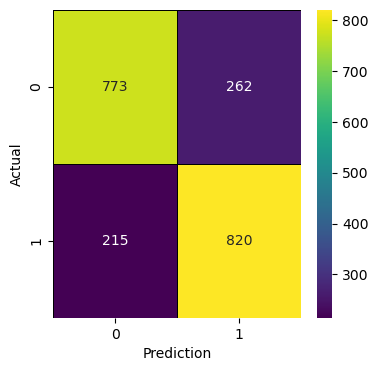

```python
# Confusion Matrix visualization

DT_confusion_matrix_tuned_sm = metrics.confusion_matrix(y_test_sm,DT_y_pred_test_tuned_sm)


f, ax = plt.subplots(figsize=(4,4))
sns.heatmap(DT_confusion_matrix_tuned_sm,annot = True, linewidths=0.5,linecolor="black",fmt=".0f",ax=ax,cmap='viridis')
plt.xlabel("Prediction")
plt.ylabel("Actual")
plt.show()
```

**Observation:**

- The confusion matrix shows that the model is better at predicting the positive class (1) than the negative class (0).

##### Random Forrest Classification

```python
# Grid searching key hyperparameters for Random Forrest Classification

from sklearn.ensemble import RandomForestClassifier

# Create object of the class

RFmodel_hpt = RandomForestClassifier()

# Parameters

params = {
    'n_estimators': [50, 100, 200],
    'max_depth': [2, 3, 5, 10, 20],
    'min_samples_split': [2, 5, 10, 15],
    'criterion': ["gini", "entropy"],
    'min_samples_leaf': [5, 10, 20, 50, 100]
}


# Define grid search

cv = RepeatedStratifiedKFold(n_splits=10, n_repeats=3, random_state=123)
grid_search = GridSearchCV(estimator=RFmodel_hpt, param_grid=params, n_jobs=-1, cv=cv, scoring='accuracy',error_score=0)
grid_result = grid_search.fit(x_train, y_train)

# Results

print("Best: %f using %s" % (grid_result.best_score_, grid_result.best_params_))
means = grid_result.cv_results_['mean_test_score']
stds = grid_result.cv_results_['std_test_score']
params = grid_result.cv_results_['params']
for mean, stdev, param in zip(means, stds, params):
    print("%f (%f) with: %r" % (mean, stdev, param))
```

```
Best: 0.805286 using {'criterion': 'entropy', 'max_depth': 10, 'min_samples_leaf': 5, 'min_samples_split': 10, 'n_estimators': 100}
0.752218 (0.011345) with: {'criterion': 'gini', 'max_depth': 2, 'min_samples_leaf': 5, 'min_samples_split': 2, 'n_estimators': 50}
0.750973 (0.009165) with: {'criterion': 'gini', 'max_depth': 2, 'min_samples_leaf': 5, 'min_samples_split': 2, 'n_estimators': 100}
0.753402 (0.007868) with: {'criterion': 'gini', 'max_depth': 2, 'min_samples_leaf': 5, 'min_samples_split': 2, 'n_estimators': 200}
0.748493 (0.012679) with: {'criterion': 'gini', 'max_depth': 2, 'min_samples_leaf': 5, 'min_samples_split': 5, 'n_estimators': 50}
0.754585 (0.009463) with: {'criterion': 'gini', 'max_depth': 2, 'min_samples_leaf': 5, 'min_samples_split': 5, 'n_estimators': 100}
0.753816 (0.009703) with: {'criterion': 'gini', 'max_depth': 2, 'min_samples_leaf': 5, 'min_samples_split': 5, 'n_estimators': 200}
0.749437 (0.010366) with: {'criterion': 'gini', 'max_depth': 2, 'min_samples_leaf': 5, 'min_samples_split': 10, 'n_estimators': 50}
0.751921 (0.010053) with: {'criterion': 'gini', 'max_depth': 2, 'min_samples_leaf': 5, 'min_samples_split': 10, 'n_estimators': 100}
0.752100 (0.008865) with: {'criterion': 'gini', 'max_depth': 2, 'min_samples_leaf': 5, 'min_samples_split': 10, 'n_estimators': 200}
0.755233 (0.014636) with: {'criterion': 'gini', 'max_depth': 2, 'min_samples_leaf': 5, 'min_samples_split': 15, 'n_estimators': 50}
0.751272 (0.009290) with: {'criterion': 'gini', 'max_depth': 2, 'min_samples_leaf': 5, 'min_samples_split': 15, 'n_estimators': 100}
0.752394 (0.007727) with: {'criterion': 'gini', 'max_depth': 2, 'min_samples_leaf': 5, 'min_samples_split': 15, 'n_estimators': 200}
0.751214 (0.012032) with: {'criterion': 'gini', 'max_depth': 2, 'min_samples_leaf': 10, 'min_samples_split': 2, 'n_estimators': 50}
0.751509 (0.010780) with: {'criterion': 'gini', 'max_depth': 2, 'min_samples_leaf': 10, 'min_samples_split': 2, 'n_estimators': 100}
0.754113 (0.007813) with: {'criterion': 'gini', 'max_depth': 2, 'min_samples_leaf': 10, 'min_samples_split': 2, 'n_estimators': 200}
0.751507 (0.011328) with: {'criterion': 'gini', 'max_depth': 2, 'min_samples_leaf': 10, 'min_samples_split': 5, 'n_estimators': 50}
0.752634 (0.008411) with: {'criterion': 'gini', 'max_depth': 2, 'min_samples_leaf': 10, 'min_samples_split': 5, 'n_estimators': 100}
0.751627 (0.007364) with: {'criterion': 'gini', 'max_depth': 2, 'min_samples_leaf': 10, 'min_samples_split': 5, 'n_estimators': 200}
0.752929 (0.012292) with: {'criterion': 'gini', 'max_depth': 2, 'min_samples_leaf': 10, 'min_samples_split': 10, 'n_estimators': 50}
0.749435 (0.009748) with: {'criterion': 'gini', 'max_depth': 2, 'min_samples_leaf': 10, 'min_samples_split': 10, 'n_estimators': 100}
0.752632 (0.009237) with: {'criterion': 'gini', 'max_depth': 2, 'min_samples_leaf': 10, 'min_samples_split': 10, 'n_estimators': 200}
0.754405 (0.011568) with: {'criterion': 'gini', 'max_depth': 2, 'min_samples_leaf': 10, 'min_samples_split': 15, 'n_estimators': 50}
0.753519 (0.010055) with: {'criterion': 'gini', 'max_depth': 2, 'min_samples_leaf': 10, 'min_samples_split': 15, 'n_estimators': 100}
0.752750 (0.009855) with: {'criterion': 'gini', 'max_depth': 2, 'min_samples_leaf': 10, 'min_samples_split': 15, 'n_estimators': 200}
0.752929 (0.010646) with: {'criterion': 'gini', 'max_depth': 2, 'min_samples_leaf': 20, 'min_samples_split': 2, 'n_estimators': 50}
0.751629 (0.009838) with: {'criterion': 'gini', 'max_depth': 2, 'min_samples_leaf': 20, 'min_samples_split': 2, 'n_estimators': 100}
0.752161 (0.008400) with: {'criterion': 'gini', 'max_depth': 2, 'min_samples_leaf': 20, 'min_samples_split': 2, 'n_estimators': 200}
0.755531 (0.013186) with: {'criterion': 'gini', 'max_depth': 2, 'min_samples_leaf': 20, 'min_samples_split': 5, 'n_estimators': 50}
0.752217 (0.006573) with: {'criterion': 'gini', 'max_depth': 2, 'min_samples_leaf': 20, 'min_samples_split': 5, 'n_estimators': 100}
0.754644 (0.006635) with: {'criterion': 'gini', 'max_depth': 2, 'min_samples_leaf': 20, 'min_samples_split': 5, 'n_estimators': 200}
0.751922 (0.011866) with: {'criterion': 'gini', 'max_depth': 2, 'min_samples_leaf': 20, 'min_samples_split': 10, 'n_estimators': 50}
0.749438 (0.009234) with: {'criterion': 'gini', 'max_depth': 2, 'min_samples_leaf': 20, 'min_samples_split': 10, 'n_estimators': 100}
0.753286 (0.007465) with: {'criterion': 'gini', 'max_depth': 2, 'min_samples_leaf': 20, 'min_samples_split': 10, 'n_estimators': 200}
0.754526 (0.011166) with: {'criterion': 'gini', 'max_depth': 2, 'min_samples_leaf': 20, 'min_samples_split': 15, 'n_estimators': 50}
0.749735 (0.009021) with: {'criterion': 'gini', 'max_depth': 2, 'min_samples_leaf': 20, 'min_samples_split': 15, 'n_estimators': 100}
0.752695 (0.008886) with: {'criterion': 'gini', 'max_depth': 2, 'min_samples_leaf': 20, 'min_samples_split': 15, 'n_estimators': 200}
0.751685 (0.011233) with: {'criterion': 'gini', 'max_depth': 2, 'min_samples_leaf': 50, 'min_samples_split': 2, 'n_estimators': 50}
0.750978 (0.010548) with: {'criterion': 'gini', 'max_depth': 2, 'min_samples_leaf': 50, 'min_samples_split': 2, 'n_estimators': 100}
0.752275 (0.008606) with: {'criterion': 'gini', 'max_depth': 2, 'min_samples_leaf': 50, 'min_samples_split': 2, 'n_estimators': 200}
```

[output cut: 546 more lines]

```
0.798125 (0.018146) with: {'criterion': 'entropy', 'max_depth': 20, 'min_samples_leaf': 50, 'min_samples_split': 15, 'n_estimators': 50}
0.797652 (0.017520) with: {'criterion': 'entropy', 'max_depth': 20, 'min_samples_leaf': 50, 'min_samples_split': 15, 'n_estimators': 100}
0.797711 (0.017059) with: {'criterion': 'entropy', 'max_depth': 20, 'min_samples_leaf': 50, 'min_samples_split': 15, 'n_estimators': 200}
0.793334 (0.015546) with: {'criterion': 'entropy', 'max_depth': 20, 'min_samples_leaf': 100, 'min_samples_split': 2, 'n_estimators': 50}
0.792151 (0.016050) with: {'criterion': 'entropy', 'max_depth': 20, 'min_samples_leaf': 100, 'min_samples_split': 2, 'n_estimators': 100}
0.793394 (0.015465) with: {'criterion': 'entropy', 'max_depth': 20, 'min_samples_leaf': 100, 'min_samples_split': 2, 'n_estimators': 200}
0.792980 (0.015782) with: {'criterion': 'entropy', 'max_depth': 20, 'min_samples_leaf': 100, 'min_samples_split': 5, 'n_estimators': 50}
0.792860 (0.016023) with: {'criterion': 'entropy', 'max_depth': 20, 'min_samples_leaf': 100, 'min_samples_split': 5, 'n_estimators': 100}
0.791915 (0.014571) with: {'criterion': 'entropy', 'max_depth': 20, 'min_samples_leaf': 100, 'min_samples_split': 5, 'n_estimators': 200}
0.792091 (0.015757) with: {'criterion': 'entropy', 'max_depth': 20, 'min_samples_leaf': 100, 'min_samples_split': 10, 'n_estimators': 50}
0.790908 (0.015971) with: {'criterion': 'entropy', 'max_depth': 20, 'min_samples_leaf': 100, 'min_samples_split': 10, 'n_estimators': 100}
0.793631 (0.014729) with: {'criterion': 'entropy', 'max_depth': 20, 'min_samples_leaf': 100, 'min_samples_split': 10, 'n_estimators': 200}
0.795287 (0.016179) with: {'criterion': 'entropy', 'max_depth': 20, 'min_samples_leaf': 100, 'min_samples_split': 15, 'n_estimators': 50}
0.792506 (0.015051) with: {'criterion': 'entropy', 'max_depth': 20, 'min_samples_leaf': 100, 'min_samples_split': 15, 'n_estimators': 100}
0.792152 (0.015414) with: {'criterion': 'entropy', 'max_depth': 20, 'min_samples_leaf': 100, 'min_samples_split': 15, 'n_estimators': 200}
```

**Testing the model with best parameters**

```python
from sklearn.ensemble import RandomForestClassifier
# create an object of the class

# Using the best parameters from gridsearch

RandomForestClassifier_tuned = RandomForestClassifier(n_estimators=100, criterion='entropy', max_depth=10, min_samples_leaf=5, min_samples_split=10, random_state=123)

# Train your model

RFmodel_tuned = RandomForestClassifier_tuned.fit(x_train,y_train)

#Prediction

#Train set
RF_y_pred_train_tuned = RFmodel_tuned.predict(x_train)

#Test set
RF_y_pred_test_tuned = RFmodel_tuned.predict(x_test)

# generate evaluation metrics

#Accuracy
print ("\nTrain Accuracy after Hyperparameter tuning:", metrics.accuracy_score(y_train, RF_y_pred_train_tuned))
print ("\nTest Accuracy after Hyperparameter tuning:", metrics.accuracy_score(y_test, RF_y_pred_test_tuned))

#Area under curve
print ("\nTrain AUC after Hyperparameter tuning:", metrics.roc_auc_score(y_train, RF_y_pred_train_tuned))
print ("\nTest AUC after Hyperparameter tuning:", metrics.roc_auc_score(y_test, RF_y_pred_test_tuned))

#Confusion matrix of test
print ("\nConfusion matrix after Hyperparameter tuning:\n\n",metrics.confusion_matrix(y_test,RF_y_pred_test_tuned))

#Classification report of test
print ("\nclassification report after Hyperparameter tuning:\n\n\n", metrics.classification_report(y_test,RF_y_pred_test_tuned))
```

```
Train Accuracy after Hyperparameter tuning: 0.837770678026269

Test Accuracy after Hyperparameter tuning: 0.8069552874378992

Train AUC after Hyperparameter tuning: 0.7554171471143645

Test AUC after Hyperparameter tuning: 0.7106448112841974

Confusion matrix after Hyperparameter tuning:

 [[948  87]
 [185 189]]

classification report after Hyperparameter tuning:


               precision    recall  f1-score   support

           0       0.84      0.92      0.87      1035
           1       0.68      0.51      0.58       374

    accuracy                           0.81      1409
   macro avg       0.76      0.71      0.73      1409
weighted avg       0.80      0.81      0.80      1409
```

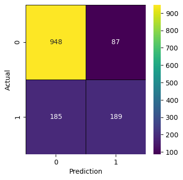

```python
# Confusion Matrix visualization

RF_confusion_matrix_tuned = metrics.confusion_matrix(y_test,RF_y_pred_test_tuned)


f, ax = plt.subplots(figsize=(4,4))
sns.heatmap(RF_confusion_matrix_tuned,annot = True, linewidths=0.5,linecolor="black",fmt=".0f",ax=ax,cmap='viridis')
plt.xlabel("Prediction")
plt.ylabel("Actual")
plt.show()
```

**Using SMOTE train-test-split**

```python
# Grid searching key hyperparameters for Random Forrest Classification

from sklearn.ensemble import RandomForestClassifier

# Create object of the class

RFmodel_hpt_sm = RandomForestClassifier()

# Parameters

params = {
    'n_estimators': [50, 100, 200],
    'max_depth': [2, 3, 5, 10, 20],
    'min_samples_split': [2, 5, 10, 15],
    'criterion': ["gini", "entropy"],
    'min_samples_leaf': [5, 10, 20, 50, 100]
}


# Define grid search

cv = RepeatedStratifiedKFold(n_splits=10, n_repeats=3, random_state=123)
grid_search = GridSearchCV(estimator=RFmodel_hpt_sm, param_grid=params, n_jobs=-1, cv=cv, scoring='accuracy',error_score=0)
grid_result = grid_search.fit(x_train_sm, y_train_sm)

# Results

print("Best: %f using %s" % (grid_result.best_score_, grid_result.best_params_))
means = grid_result.cv_results_['mean_test_score']
stds = grid_result.cv_results_['std_test_score']
params = grid_result.cv_results_['params']
for mean, stdev, param in zip(means, stds, params):
    print("%f (%f) with: %r" % (mean, stdev, param))
```

```
Best: 0.838044 using {'criterion': 'entropy', 'max_depth': 20, 'min_samples_leaf': 5, 'min_samples_split': 2, 'n_estimators': 200}
0.770758 (0.014892) with: {'criterion': 'gini', 'max_depth': 2, 'min_samples_leaf': 5, 'min_samples_split': 2, 'n_estimators': 50}
0.773457 (0.014576) with: {'criterion': 'gini', 'max_depth': 2, 'min_samples_leaf': 5, 'min_samples_split': 2, 'n_estimators': 100}
0.773699 (0.015718) with: {'criterion': 'gini', 'max_depth': 2, 'min_samples_leaf': 5, 'min_samples_split': 2, 'n_estimators': 200}
0.772370 (0.017404) with: {'criterion': 'gini', 'max_depth': 2, 'min_samples_leaf': 5, 'min_samples_split': 5, 'n_estimators': 50}
0.773377 (0.016868) with: {'criterion': 'gini', 'max_depth': 2, 'min_samples_leaf': 5, 'min_samples_split': 5, 'n_estimators': 100}
0.775873 (0.014784) with: {'criterion': 'gini', 'max_depth': 2, 'min_samples_leaf': 5, 'min_samples_split': 5, 'n_estimators': 200}
0.770719 (0.015908) with: {'criterion': 'gini', 'max_depth': 2, 'min_samples_leaf': 5, 'min_samples_split': 10, 'n_estimators': 50}
0.773134 (0.016722) with: {'criterion': 'gini', 'max_depth': 2, 'min_samples_leaf': 5, 'min_samples_split': 10, 'n_estimators': 100}
0.773699 (0.014675) with: {'criterion': 'gini', 'max_depth': 2, 'min_samples_leaf': 5, 'min_samples_split': 10, 'n_estimators': 200}
0.772127 (0.015128) with: {'criterion': 'gini', 'max_depth': 2, 'min_samples_leaf': 5, 'min_samples_split': 15, 'n_estimators': 50}
0.773255 (0.016393) with: {'criterion': 'gini', 'max_depth': 2, 'min_samples_leaf': 5, 'min_samples_split': 15, 'n_estimators': 100}
0.774665 (0.015548) with: {'criterion': 'gini', 'max_depth': 2, 'min_samples_leaf': 5, 'min_samples_split': 15, 'n_estimators': 200}
0.770758 (0.015850) with: {'criterion': 'gini', 'max_depth': 2, 'min_samples_leaf': 10, 'min_samples_split': 2, 'n_estimators': 50}
0.772973 (0.016182) with: {'criterion': 'gini', 'max_depth': 2, 'min_samples_leaf': 10, 'min_samples_split': 2, 'n_estimators': 100}
0.774464 (0.016304) with: {'criterion': 'gini', 'max_depth': 2, 'min_samples_leaf': 10, 'min_samples_split': 2, 'n_estimators': 200}
0.771484 (0.015600) with: {'criterion': 'gini', 'max_depth': 2, 'min_samples_leaf': 10, 'min_samples_split': 5, 'n_estimators': 50}
0.773538 (0.017442) with: {'criterion': 'gini', 'max_depth': 2, 'min_samples_leaf': 10, 'min_samples_split': 5, 'n_estimators': 100}
0.774142 (0.016741) with: {'criterion': 'gini', 'max_depth': 2, 'min_samples_leaf': 10, 'min_samples_split': 5, 'n_estimators': 200}
0.772451 (0.016375) with: {'criterion': 'gini', 'max_depth': 2, 'min_samples_leaf': 10, 'min_samples_split': 10, 'n_estimators': 50}
0.775390 (0.015907) with: {'criterion': 'gini', 'max_depth': 2, 'min_samples_leaf': 10, 'min_samples_split': 10, 'n_estimators': 100}
0.773900 (0.015600) with: {'criterion': 'gini', 'max_depth': 2, 'min_samples_leaf': 10, 'min_samples_split': 10, 'n_estimators': 200}
0.771364 (0.015532) with: {'criterion': 'gini', 'max_depth': 2, 'min_samples_leaf': 10, 'min_samples_split': 15, 'n_estimators': 50}
0.773940 (0.015598) with: {'criterion': 'gini', 'max_depth': 2, 'min_samples_leaf': 10, 'min_samples_split': 15, 'n_estimators': 100}
0.772289 (0.016732) with: {'criterion': 'gini', 'max_depth': 2, 'min_samples_leaf': 10, 'min_samples_split': 15, 'n_estimators': 200}
0.774182 (0.015223) with: {'criterion': 'gini', 'max_depth': 2, 'min_samples_leaf': 20, 'min_samples_split': 2, 'n_estimators': 50}
0.773296 (0.017628) with: {'criterion': 'gini', 'max_depth': 2, 'min_samples_leaf': 20, 'min_samples_split': 2, 'n_estimators': 100}
0.773780 (0.015400) with: {'criterion': 'gini', 'max_depth': 2, 'min_samples_leaf': 20, 'min_samples_split': 2, 'n_estimators': 200}
0.772410 (0.019130) with: {'criterion': 'gini', 'max_depth': 2, 'min_samples_leaf': 20, 'min_samples_split': 5, 'n_estimators': 50}
0.775631 (0.013893) with: {'criterion': 'gini', 'max_depth': 2, 'min_samples_leaf': 20, 'min_samples_split': 5, 'n_estimators': 100}
0.774423 (0.017266) with: {'criterion': 'gini', 'max_depth': 2, 'min_samples_leaf': 20, 'min_samples_split': 5, 'n_estimators': 200}
0.773538 (0.016362) with: {'criterion': 'gini', 'max_depth': 2, 'min_samples_leaf': 20, 'min_samples_split': 10, 'n_estimators': 50}
0.773135 (0.015183) with: {'criterion': 'gini', 'max_depth': 2, 'min_samples_leaf': 20, 'min_samples_split': 10, 'n_estimators': 100}
0.774383 (0.015090) with: {'criterion': 'gini', 'max_depth': 2, 'min_samples_leaf': 20, 'min_samples_split': 10, 'n_estimators': 200}
0.771887 (0.015508) with: {'criterion': 'gini', 'max_depth': 2, 'min_samples_leaf': 20, 'min_samples_split': 15, 'n_estimators': 50}
0.773135 (0.015981) with: {'criterion': 'gini', 'max_depth': 2, 'min_samples_leaf': 20, 'min_samples_split': 15, 'n_estimators': 100}
0.774262 (0.014458) with: {'criterion': 'gini', 'max_depth': 2, 'min_samples_leaf': 20, 'min_samples_split': 15, 'n_estimators': 200}
0.770880 (0.015389) with: {'criterion': 'gini', 'max_depth': 2, 'min_samples_leaf': 50, 'min_samples_split': 2, 'n_estimators': 50}
0.772893 (0.015131) with: {'criterion': 'gini', 'max_depth': 2, 'min_samples_leaf': 50, 'min_samples_split': 2, 'n_estimators': 100}
0.773699 (0.014472) with: {'criterion': 'gini', 'max_depth': 2, 'min_samples_leaf': 50, 'min_samples_split': 2, 'n_estimators': 200}
```

[output cut: 546 more lines]

```
0.798704 (0.014432) with: {'criterion': 'entropy', 'max_depth': 20, 'min_samples_leaf': 50, 'min_samples_split': 15, 'n_estimators': 50}
0.799750 (0.015814) with: {'criterion': 'entropy', 'max_depth': 20, 'min_samples_leaf': 50, 'min_samples_split': 15, 'n_estimators': 100}
0.799590 (0.014744) with: {'criterion': 'entropy', 'max_depth': 20, 'min_samples_leaf': 50, 'min_samples_split': 15, 'n_estimators': 200}
0.788597 (0.014667) with: {'criterion': 'entropy', 'max_depth': 20, 'min_samples_leaf': 100, 'min_samples_split': 2, 'n_estimators': 50}
0.790167 (0.014582) with: {'criterion': 'entropy', 'max_depth': 20, 'min_samples_leaf': 100, 'min_samples_split': 2, 'n_estimators': 100}
0.787712 (0.015510) with: {'criterion': 'entropy', 'max_depth': 20, 'min_samples_leaf': 100, 'min_samples_split': 2, 'n_estimators': 200}
0.789443 (0.013088) with: {'criterion': 'entropy', 'max_depth': 20, 'min_samples_leaf': 100, 'min_samples_split': 5, 'n_estimators': 50}
0.789282 (0.014742) with: {'criterion': 'entropy', 'max_depth': 20, 'min_samples_leaf': 100, 'min_samples_split': 5, 'n_estimators': 100}
0.788356 (0.014633) with: {'criterion': 'entropy', 'max_depth': 20, 'min_samples_leaf': 100, 'min_samples_split': 5, 'n_estimators': 200}
0.788194 (0.012750) with: {'criterion': 'entropy', 'max_depth': 20, 'min_samples_leaf': 100, 'min_samples_split': 10, 'n_estimators': 50}
0.789242 (0.015776) with: {'criterion': 'entropy', 'max_depth': 20, 'min_samples_leaf': 100, 'min_samples_split': 10, 'n_estimators': 100}
0.788396 (0.015044) with: {'criterion': 'entropy', 'max_depth': 20, 'min_samples_leaf': 100, 'min_samples_split': 10, 'n_estimators': 200}
0.788677 (0.014230) with: {'criterion': 'entropy', 'max_depth': 20, 'min_samples_leaf': 100, 'min_samples_split': 15, 'n_estimators': 50}
0.790208 (0.013198) with: {'criterion': 'entropy', 'max_depth': 20, 'min_samples_leaf': 100, 'min_samples_split': 15, 'n_estimators': 100}
0.788154 (0.014721) with: {'criterion': 'entropy', 'max_depth': 20, 'min_samples_leaf': 100, 'min_samples_split': 15, 'n_estimators': 200}
```

```python
from sklearn.ensemble import RandomForestClassifier
# create an object of the class

# Using the best parameters from gridsearch

RandomForestClassifier_tuned_sm = RandomForestClassifier(n_estimators=200, criterion='entropy', max_depth=20, min_samples_leaf=5, min_samples_split=2, random_state=123)

# Train your model

RFmodel_tuned_sm = RandomForestClassifier_tuned_sm.fit(x_train_sm,y_train_sm)

#Prediction

#Train set
RF_y_pred_train_tuned_sm = RFmodel_tuned_sm.predict(x_train_sm)

#Test set
RF_y_pred_test_tuned_sm = RFmodel_tuned_sm.predict(x_test_sm)

# generate evaluation metrics

#Accuracy
print ("\nTrain Accuracy after Hyperparameter tuning:", metrics.accuracy_score(y_train_sm, RF_y_pred_train_tuned_sm))
print ("\nTest Accuracy after Hyperparameter tuning:", metrics.accuracy_score(y_test_sm, RF_y_pred_test_tuned_sm))

#Area under curve
print ("\nTrain AUC after Hyperparameter tuning:", metrics.roc_auc_score(y_train_sm, RF_y_pred_train_tuned_sm))
print ("\nTest AUC after Hyperparameter tuning:", metrics.roc_auc_score(y_test_sm, RF_y_pred_test_tuned_sm))

#Confusion matrix of test
print ("\nConfusion matrix after Hyperparameter tuning:\n\n",metrics.confusion_matrix(y_test_sm,RF_y_pred_test_tuned_sm))

#Classification report of test
print ("\nclassification report after Hyperparameter tuning:\n\n\n", metrics.classification_report(y_test_sm,RF_y_pred_test_tuned_sm))
```

```
Train Accuracy after Hyperparameter tuning: 0.896955786421841

Test Accuracy after Hyperparameter tuning: 0.8130434782608695

Train AUC after Hyperparameter tuning: 0.896955786421841

Test AUC after Hyperparameter tuning: 0.8130434782608696

Confusion matrix after Hyperparameter tuning:

 [[843 192]
 [195 840]]

classification report after Hyperparameter tuning:


               precision    recall  f1-score   support

           0       0.81      0.81      0.81      1035
           1       0.81      0.81      0.81      1035

    accuracy                           0.81      2070
   macro avg       0.81      0.81      0.81      2070
weighted avg       0.81      0.81      0.81      2070
```

**Observation:**

Overall, it seems that the Random Forest Classifier is a better model than the decision tree classifier in terms of accuracy and generalization, but there is still room for improvement in terms of distinguishing between the two classes. Further optimization may help improve the model's performance.

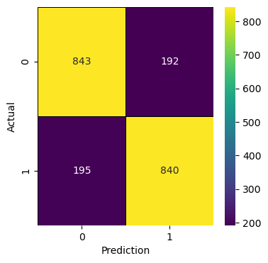

```python
# Confusion Matrix visualization

RF_confusion_matrix_tuned_sm = metrics.confusion_matrix(y_test_sm,RF_y_pred_test_tuned_sm)


f, ax = plt.subplots(figsize=(4,4))
sns.heatmap(RF_confusion_matrix_tuned_sm,annot = True, linewidths=0.5,linecolor="black",fmt=".0f",ax=ax,cmap='viridis')
plt.xlabel("Prediction")
plt.ylabel("Actual")
plt.show()
```

**Observation:**

##### Support Vector Machine

```python
# Grid searching key hyperparameters for Support Vector Machine

from sklearn.svm import SVC

# Create object of the class

SVCmodel_hpt = SVC(probability=True)

# Parameters

params = {
    'kernel': ['poly', 'rbf', 'sigmoid'],
    'C': [50, 10, 1.0, 0.1, 0.01],
    'gamma': ['scale','auto']
}


# Define grid search

cv = RepeatedStratifiedKFold(n_splits=10, n_repeats=3, random_state=123)
grid_search = GridSearchCV(estimator=SVCmodel_hpt, param_grid=params, n_jobs=-1, cv=cv, scoring='accuracy',error_score=0)
grid_result = grid_search.fit(x_train, y_train)

# Results

print("Best: %f using %s" % (grid_result.best_score_, grid_result.best_params_))
means = grid_result.cv_results_['mean_test_score']
stds = grid_result.cv_results_['std_test_score']
params = grid_result.cv_results_['params']
for mean, stdev, param in zip(means, stds, params):
    print("%f (%f) with: %r" % (mean, stdev, param))
```

```
Best: 0.798365 using {'C': 1.0, 'gamma': 'scale', 'kernel': 'rbf'}
0.754349 (0.017470) with: {'C': 50, 'gamma': 'scale', 'kernel': 'poly'}
0.754346 (0.017443) with: {'C': 50, 'gamma': 'scale', 'kernel': 'rbf'}
0.729972 (0.017657) with: {'C': 50, 'gamma': 'scale', 'kernel': 'sigmoid'}
0.754467 (0.017535) with: {'C': 50, 'gamma': 'auto', 'kernel': 'poly'}
0.754227 (0.017409) with: {'C': 50, 'gamma': 'auto', 'kernel': 'rbf'}
0.732045 (0.018168) with: {'C': 50, 'gamma': 'auto', 'kernel': 'sigmoid'}
0.774404 (0.018590) with: {'C': 10, 'gamma': 'scale', 'kernel': 'poly'}
0.783633 (0.018232) with: {'C': 10, 'gamma': 'scale', 'kernel': 'rbf'}
0.732516 (0.016445) with: {'C': 10, 'gamma': 'scale', 'kernel': 'sigmoid'}
0.774582 (0.018581) with: {'C': 10, 'gamma': 'auto', 'kernel': 'poly'}
0.783751 (0.018161) with: {'C': 10, 'gamma': 'auto', 'kernel': 'rbf'}
0.736598 (0.016286) with: {'C': 10, 'gamma': 'auto', 'kernel': 'sigmoid'}
0.796177 (0.019109) with: {'C': 1.0, 'gamma': 'scale', 'kernel': 'poly'}
0.798365 (0.021488) with: {'C': 1.0, 'gamma': 'scale', 'kernel': 'rbf'}
0.746242 (0.016049) with: {'C': 1.0, 'gamma': 'scale', 'kernel': 'sigmoid'}
0.796118 (0.019136) with: {'C': 1.0, 'gamma': 'auto', 'kernel': 'poly'}
0.798306 (0.021527) with: {'C': 1.0, 'gamma': 'auto', 'kernel': 'rbf'}
0.746006 (0.018033) with: {'C': 1.0, 'gamma': 'auto', 'kernel': 'sigmoid'}
0.774936 (0.009030) with: {'C': 0.1, 'gamma': 'scale', 'kernel': 'poly'}
0.794105 (0.017177) with: {'C': 0.1, 'gamma': 'scale', 'kernel': 'rbf'}
0.793161 (0.018856) with: {'C': 0.1, 'gamma': 'scale', 'kernel': 'sigmoid'}
0.774699 (0.009084) with: {'C': 0.1, 'gamma': 'auto', 'kernel': 'poly'}
0.794105 (0.017177) with: {'C': 0.1, 'gamma': 'auto', 'kernel': 'rbf'}
0.793042 (0.019146) with: {'C': 0.1, 'gamma': 'auto', 'kernel': 'sigmoid'}
0.734647 (0.000712) with: {'C': 0.01, 'gamma': 'scale', 'kernel': 'poly'}
0.734647 (0.000712) with: {'C': 0.01, 'gamma': 'scale', 'kernel': 'rbf'}
0.734647 (0.000712) with: {'C': 0.01, 'gamma': 'scale', 'kernel': 'sigmoid'}
0.734647 (0.000712) with: {'C': 0.01, 'gamma': 'auto', 'kernel': 'poly'}
0.734647 (0.000712) with: {'C': 0.01, 'gamma': 'auto', 'kernel': 'rbf'}
0.734647 (0.000712) with: {'C': 0.01, 'gamma': 'auto', 'kernel': 'sigmoid'}
```

**Testing the model with best parameters**

```python
from sklearn.svm import SVC
# create an object of the class

# Using the best parameters from gridsearch. Best parameters are default parameters

SupportVectorClassifier_tuned = SVC(probability=True)

# Train your model

SVCmodel_tuned = SupportVectorClassifier_tuned.fit(x_train,y_train)

#Prediction

#Train set
SVC_y_pred_train_tuned = SVCmodel_tuned.predict(x_train)

#Test set
SVC_y_pred_test_tuned = SVCmodel_tuned.predict(x_test)

# generate evaluation metrics

#Accuracy
print ("\nTrain Accuracy after Hyperparameter tuning:", metrics.accuracy_score(y_train, SVC_y_pred_train_tuned))
print ("\nTest Accuracy after Hyperparameter tuning:", metrics.accuracy_score(y_test, SVC_y_pred_test_tuned))

#Area under curve
print ("\nTrain AUC after Hyperparameter tuning:", metrics.roc_auc_score(y_train, SVC_y_pred_train_tuned))
print ("\nTest AUC after Hyperparameter tuning:", metrics.roc_auc_score(y_test, SVC_y_pred_test_tuned))

#Confusion matrix of test
print ("\nConfusion matrix after Hyperparameter tuning:\n\n",metrics.confusion_matrix(y_test,SVC_y_pred_test_tuned))

#Classification report of test
print ("\nclassification report after Hyperparameter tuning:\n\n\n", metrics.classification_report(y_test,SVC_y_pred_test_tuned))
```

```
Train Accuracy after Hyperparameter tuning: 0.8182463613773517

Test Accuracy after Hyperparameter tuning: 0.7934705464868701

Train AUC after Hyperparameter tuning: 0.7290965051419689

Test AUC after Hyperparameter tuning: 0.6946356144565862

Confusion matrix after Hyperparameter tuning:

 [[937  98]
 [193 181]]

classification report after Hyperparameter tuning:


               precision    recall  f1-score   support

           0       0.83      0.91      0.87      1035
           1       0.65      0.48      0.55       374

    accuracy                           0.79      1409
   macro avg       0.74      0.69      0.71      1409
weighted avg       0.78      0.79      0.78      1409
```

**Observation:**

- The accuracy score for the training set is 0.818, indicating that the model has learned the training data reasonably well.
- The accuracy score for the test set is 0.793, which means that the model is able to generalize to new data.
- However, the test accuracy is lower than the Random Forest Classifier we trained previously.
- The AUC score is 0.729 for the training set and 0.695 for the test set, indicating that the model is not very good at distinguishing between the two classes.
- The confusion matrix shows that the model is better at predicting the negative class (0) than the positive class (1).
- The precision and recall scores are higher for the negative class (0) than the positive class (1), indicating that the model is better at identifying true negatives than true positives.